# Linear Models with R Chapter 1 `Introduction` Notes

# Initial data analysis

Numerical Summaries

- means
- standar deviations
- max and min
- correlations
- …

Graphical summaries:

- boxplots
- histograms
- density plots
- scatterplots

In the plots, look for outliers, data-entry erroes, skewed or unusual distributions and structure

```r
data(pima, package = "faraway")
head(pima)
```

|  | pregnant | glucose | diastolic | triceps | insulin | bmi | diabetes | age | test |
| --- | --- | --- | --- | --- | --- | --- | --- | --- | --- |
| 1 | 6 | 148 | 72 | 35 | 0 | 33.6 | 0.627 | 50 | 1 |
| 2 | 1 | 85 | 66 | 29 | 0 | 26.6 | 0.351 | 31 | 0 |
| 3 | 8 | 183 | 64 | 0 | 0 | 23.3 | 0.672 | 32 | 1 |
| 4 | 1 | 89 | 66 | 23 | 94 | 28.1 | 0.167 | 21 | 0 |
| 5 | 0 | 137 | 40 | 35 | 168 | 43.1 | 2.288 | 33 | 1 |
| 6 | 5 | 116 | 74 | 0 | 0 | 25.6 | 0.201 | 30 | 0 |

```r
summary(pima)
```

```
    pregnant         glucose        diastolic         triceps
 Min.   : 0.000   Min.   :  0.0   Min.   :  0.00   Min.   : 0.00
 1st Qu.: 1.000   1st Qu.: 99.0   1st Qu.: 62.00   1st Qu.: 0.00
 Median : 3.000   Median :117.0   Median : 72.00   Median :23.00
 Mean   : 3.845   Mean   :120.9   Mean   : 69.11   Mean   :20.54
 3rd Qu.: 6.000   3rd Qu.:140.2   3rd Qu.: 80.00   3rd Qu.:32.00
 Max.   :17.000   Max.   :199.0   Max.   :122.00   Max.   :99.00
    insulin           bmi           diabetes           age
 Min.   :  0.0   Min.   : 0.00   Min.   :0.0780   Min.   :21.00
 1st Qu.:  0.0   1st Qu.:27.30   1st Qu.:0.2437   1st Qu.:24.00
 Median : 30.5   Median :32.00   Median :0.3725   Median :29.00
 Mean   : 79.8   Mean   :31.99   Mean   :0.4719   Mean   :33.24
 3rd Qu.:127.2   3rd Qu.:36.60   3rd Qu.:0.6262   3rd Qu.:41.00
 Max.   :846.0   Max.   :67.10   Max.   :2.4200   Max.   :81.00
      test
 Min.   :0.000
 1st Qu.:0.000
 Median :0.000
 Mean   :0.349
 3rd Qu.:1.000
 Max.   :1.000
```

Note that some people have a blood pressure of 0 (diastolic), that is not possible, something must be fishy.

```r
sort(pima$diastolic)
```

```
  [1]   0   0   0   0   0   0   0   0   0   0   0   0   0   0   0   0
 [17]   0   0   0   0   0   0   0   0   0   0   0   0   0   0   0   0
 [33]   0   0   0  24  30  30  38  40  44  44  44  44  46  46  48  48
 [49]  48  48  48  50  50  50  50  50  50  50  50  50  50  50  50  50
 [65]  52  52  52  52  52  52  52  52  52  52  52  54  54  54  54  54
 [81]  54  54  54  54  54  54  55  55  56  56  56  56  56  56  56  56
 [97]  56  56  56  56  58  58  58  58  58  58  58  58  58  58  58  58
[113]  58  58  58  58  58  58  58  58  58  60  60  60  60  60  60  60
[129]  60  60  60  60  60  60  60  60  60  60  60  60  60  60  60  60
[145]  60  60  60  60  60  60  60  60  60  60  60  60  60  60  61  62
[161]  62  62  62  62  62  62  62  62  62  62  62  62  62  62  62  62
[177]  62  62  62  62  62  62  62  62  62  62  62  62  62  62  62  62
[193]  62  64  64  64  64  64  64  64  64  64  64  64  64  64  64  64
[209]  64  64  64  64  64  64  64  64  64  64  64  64  64  64  64  64
[225]  64  64  64  64  64  64  64  64  64  64  64  64  65  65  65  65
```

[output cut: 33 more lines]

Those zeros are most likely missing values, let’s set them to NA

```r
pima$diastolic[pima$diastolic == 0] <- NA
pima$glucose[pima$glucose == 0] <- NA
pima$triceps[pima$triceps == 0] <- NA
pima$insulin[pima$insulin == 0] <- NA
pima$bmi[pima$bmi == 0] <- NA
```

Test is a categorical variable, we should encode it as a factor and not numerical

```r
pima$test <- factor(pima$test)
summary(pima$test)
```

```
  0   1
500 268
```

It would be better if we used descriptive labels

```r
levels(pima$test) <- c("negative", "positive")
summary(pima)
```

```
    pregnant         glucose        diastolic
 Min.   : 0.000   Min.   : 44.0   Min.   : 24.00
 1st Qu.: 1.000   1st Qu.: 99.0   1st Qu.: 64.00
 Median : 3.000   Median :117.0   Median : 72.00
 Mean   : 3.845   Mean   :121.7   Mean   : 72.41
 3rd Qu.: 6.000   3rd Qu.:141.0   3rd Qu.: 80.00
 Max.   :17.000   Max.   :199.0   Max.   :122.00
                  NA's   :5       NA's   :35
    triceps         insulin            bmi
 Min.   : 7.00   Min.   : 14.00   Min.   :18.20
 1st Qu.:22.00   1st Qu.: 76.25   1st Qu.:27.50
 Median :29.00   Median :125.00   Median :32.30
 Mean   :29.15   Mean   :155.55   Mean   :32.46
 3rd Qu.:36.00   3rd Qu.:190.00   3rd Qu.:36.60
 Max.   :99.00   Max.   :846.00   Max.   :67.10
 NA's   :227     NA's   :374      NA's   :11
    diabetes           age              test
 Min.   :0.0780   Min.   :21.00   negative:500
 1st Qu.:0.2437   1st Qu.:24.00   positive:268
 Median :0.3725   Median :29.00
 Mean   :0.4719   Mean   :33.24
 3rd Qu.:0.6262   3rd Qu.:41.00
 Max.   :2.4200   Max.   :81.00
```

Now let’s do some plots

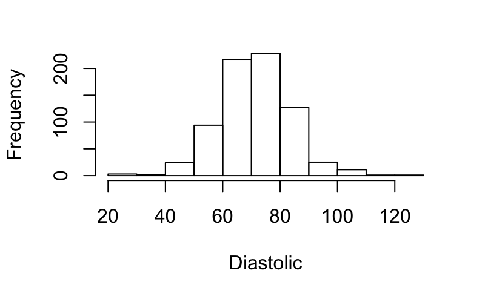

```r
hist(pima$diastolic, xlab = "Diastolic", main = "")
```

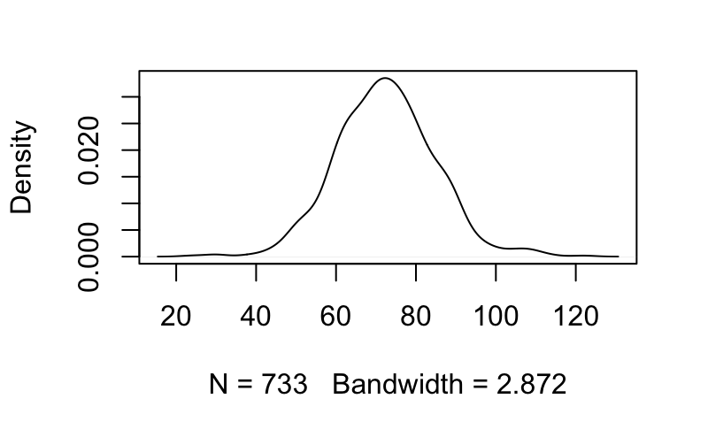

```r
plot(density(pima$diastolic, na.rm = TRUE), main = "")
```

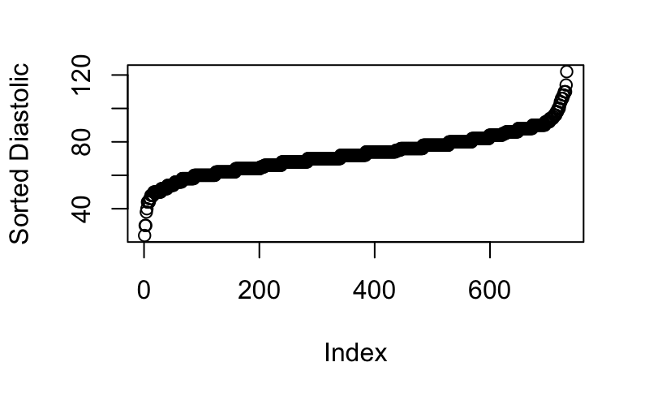

```r
plot(sort(pima$diastolic), ylab = "Sorted Diastolic")
```

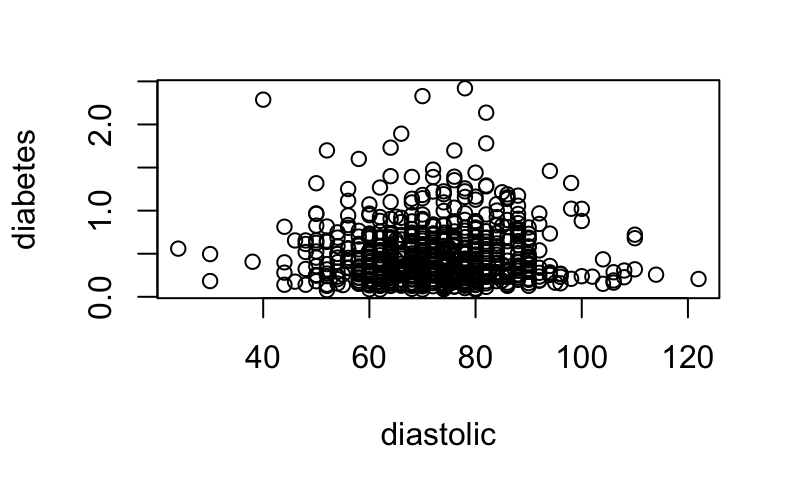

```r
plot(diabetes ~ diastolic, pima)
```

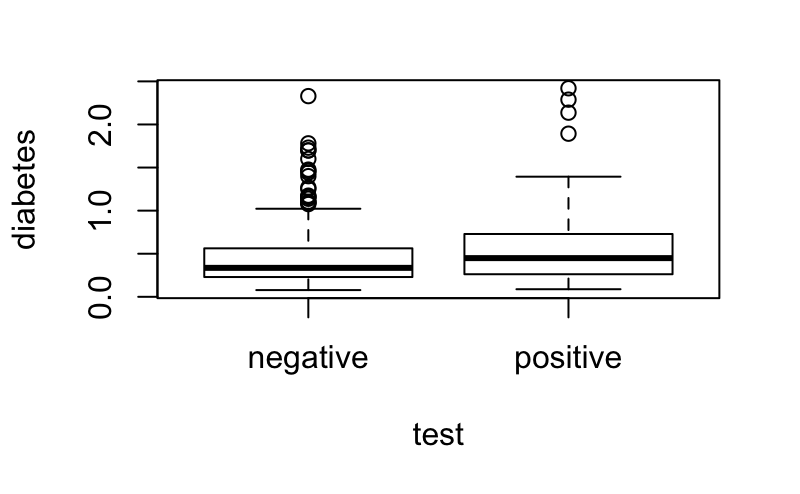

```r
plot(diabetes ~ test, pima)
```

ggplot2 allows us to produce similar versions of these plots

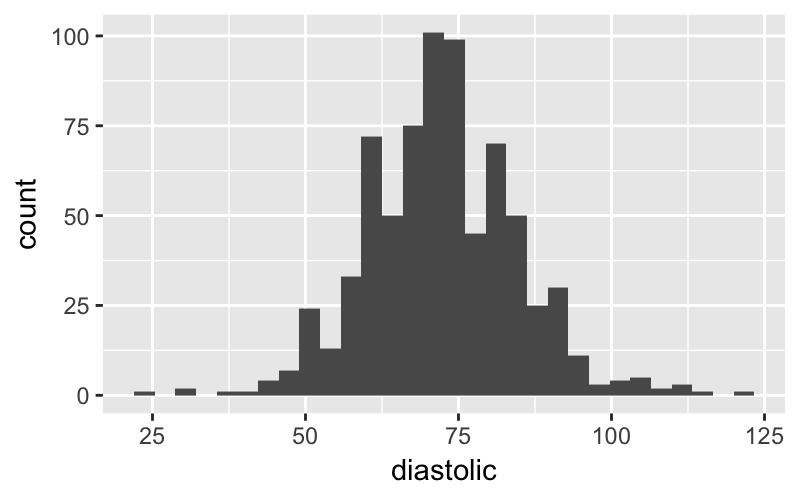

```r
require(ggplot2)
ggplot(pima, aes(x = diastolic)) + geom_histogram()
```

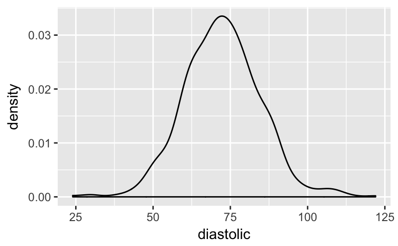

```r
ggplot(pima, aes(x = diastolic)) + geom_density()
```

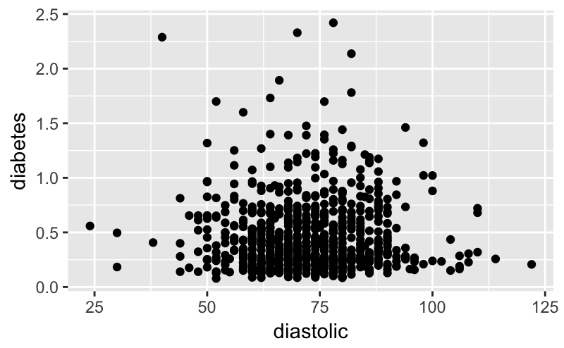

```r
ggplot(pima, aes(x = diastolic, y = diabetes)) + geom_point()
```

aes sepecifies what you see

[figure not shown]

# When to Use Linear Modeling

Linear modeling is used to explain/model the relationship between a single variable Y (called response, outcome, output, or dependent variable) and one or more predictor (or input, independent, or explanatory variables).

Linear modeling aka. regression analysis

When there are more than one predictor variable ==> multiple regression

When there are more than one response ==> multivariate regression.

Response: * must be continuous

Explanatory Variable: * can be categorical, discrete, or continuous

# History

```r
data(manilius, package = "faraway")
head(manilius)
```

|  | arc | sinang | cosang | group |
| --- | --- | --- | --- | --- |
| 1 | 13.16667 | 0.8836 | -0.4682 | 1 |
| 2 | 13.13333 | 0.9996 | -0.0282 | 1 |
| 3 | 13.20000 | 0.9899 | 0.1421 | 1 |
| 4 | 14.25000 | 0.2221 | 0.9750 | 3 |
| 5 | 14.70000 | 0.0006 | 1.0000 | 3 |
| 6 | 13.01667 | 0.9308 | -0.3654 | 1 |

```r
(moon3 <- aggregate(manilius[, 1:3], list(manilius$group), sum))
```

| Group.1 | arc | sinang | cosang |
| --- | --- | --- | --- |
| 1 | 118.1333 | 8.4987 | -0.7932 |
| 2 | 140.2833 | -6.1404 | 1.7443 |
| 3 | 127.5333 | 2.9777 | 7.9649 |

```r
solve(cbind(9, moon3$sinang, moon3$cosang), moon3$arc)
```

```
[1] 14.5445859 -1.4898221  0.1341264
```

Least Squares

$arc_i = \beta + \alpha*sinang_i + \gamma*cosang_i + \epsilon_i$

We find $\alpha$, $\beta$, and $\gamma$ that minimize the sum of the squared errors $\epsilon^2$

```r
lmod <- lm(arc ~ sinang + cosang, manilius)
coef(lmod)
```

```
(Intercept)      sinang      cosang
14.56162351 -1.50458123  0.09136504
```

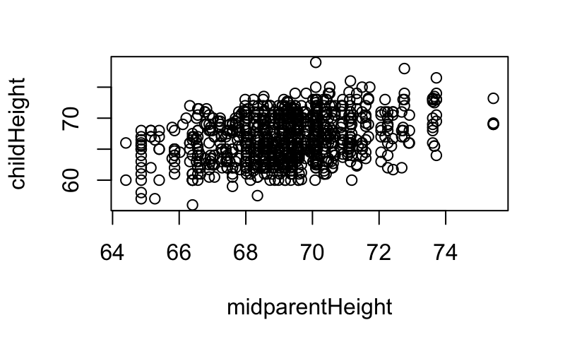

```r
data(GaltonFamilies, package = "HistData")
plot(childHeight ~ midparentHeight, GaltonFamilies)
```

We propose

$childheight = \alpha + \beta*midparentHeight + \epsilon$

```r
lmod <- lm(childHeight ~ midparentHeight, GaltonFamilies)
coef(lmod)
```

```
    (Intercept) midparentHeight
     22.6362405       0.6373609
```

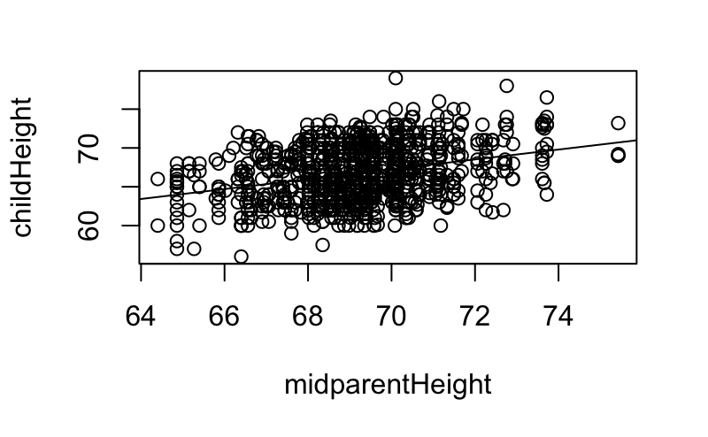

```r
plot(childHeight ~ midparentHeight, GaltonFamilies)
abline(lmod)
```

```r
beta <- with(GaltonFamilies, cor(midparentHeight, childHeight) * sd(childHeight) / sd(midparentHeight))
alpha <- with(GaltonFamilies, mean(childHeight) - beta * mean(midparentHeight))
```

```r
(beta1 <- with(GaltonFamilies, sd(childHeight) / sd(midparentHeight)))
```

```
[1] 1.985858
```

```r
(alpha1 <- with(GaltonFamilies, mean(childHeight) - beta1 * mean(midparentHeight)))
```

```
[1] -70.68889
```

```r
plot(childHeight ~ midparentHeight, GaltonFamilies)
abline(lmod)
```

[figure not shown]

```r
abline(alpha1, beta1, lty = 2)
```